# Soil Data Analysis SSURGO

Kathryn Hurchla

11/8/2021

## Introduction

Modeled after tutorial at http://ncss-tech.github.io/AQP/soilDB/SDA-tutorial.html Soil data presented were derived from the 100+ year efforts of the National Cooperative Soil Survey, c/o USDA-NRCS

## Prepare environmnet

Install and load R packages

Load these packages to your current environment (or activated virtual environment)

```r
# load packages
library(aqp)
library(plyr)
library(cluster)
library(ape)
library(colorspace)
library(soilDB)
library(sharpshootR)
library(plyr)
library(RColorBrewer)
library(latticeExtra)
library(httr)
library(rgdal)
library(raster)
library(rgeos)
library(kableExtra)
```

## Warmup with this dataset

Run an example plot showing soil color signatures

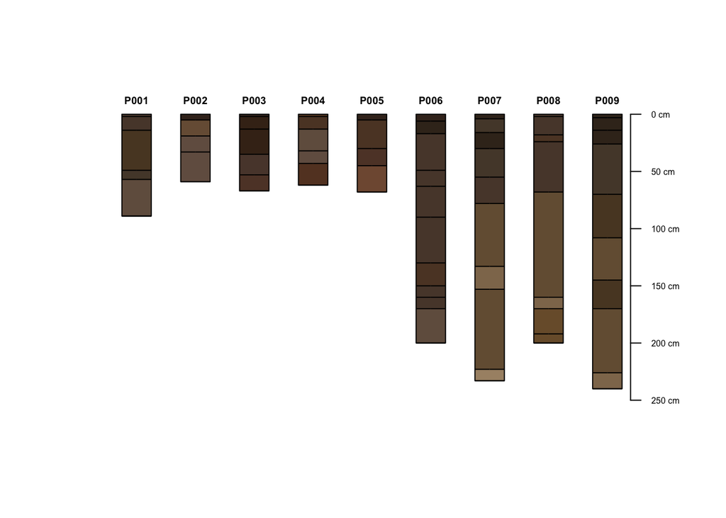

```r
# using some of the aqp package's built-in data
# according to D.E. Beaudette, Source colors are in sRGB (D65) colorspace, as
# converted from Munsell notation using aqp::munsell2rgb().
# source: http://ncss-tech.github.io/AQP/aqp/soil-color-signatures.html
data(sp1)
sp1$soil_color <- with(sp1, munsell2rgb(hue, value, chroma))
depths(sp1) <- id ~ top + bottom
plot(sp1)
```

### Now have a look at the soil color schemes

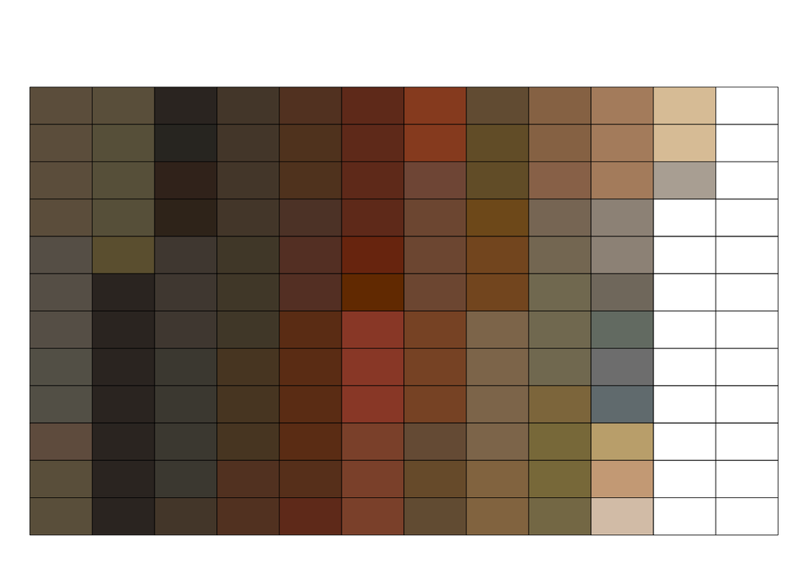

```r
# Colors from Official Series Descriptions
s.list <- c('amador', 'redding', 'pentz', 'willows', 'pardee', 'yolo', 'hanford', 'cecil', 'sycamore', 'KLAMATH', 'MOGLIA', 'vleck', 'drummer', 'CANEYHEAD', 'musick', 'sierra', 'HAYNER', 'zook', 'argonaut', 'PALAU')

# get these soil series
s <- fetchOSD(s.list)

# manually convert Munsell -> sRGB
rgb.data <- munsell2rgb(s$hue, s$value, s$chroma, return_triplets = TRUE)
s$r <- rgb.data$r
s$g <- rgb.data$g
s$b <- rgb.data$b

# Look at full range of OSD colors in this set.
# Colors, arranged by ΔE00.
previewColors(s$soil_color)
```

### Some basic queries

1. When was each survey area last exported to SSURGO? Show most recent at top.

```r
SDA_query("SELECT areasymbol, saverest FROM sacatalog WHERE areasymbol != 'US' ORDER BY saverest desc")
```

```
## single result set, returning a data.frame
```

```
##      areasymbol              saverest
## 1         OR640 10/27/2021 6:38:50 PM
## 2         OR638 10/27/2021 6:37:50 PM
## 3         OR637 10/27/2021 6:36:35 PM
## 4         OR636 10/27/2021 6:33:34 PM
## 5         OR635 10/27/2021 6:31:34 PM
## 6         OR632 10/27/2021 6:29:04 PM
## 7         OR629 10/27/2021 6:27:49 PM
## 8         OR628 10/27/2021 6:25:34 PM
## 9         OR607 10/27/2021 6:23:19 PM
## 10        OR601 10/27/2021 6:21:34 PM
## 11        OR015 10/27/2021 6:19:03 PM
## 12        OR009 10/27/2021 6:18:18 PM
## 13        OR007 10/27/2021 6:17:48 PM
## 14        OR003 10/27/2021 6:17:18 PM
```

[output cut: 3359 more lines]

2. When was the most recent updated survey in Vermont, if any exist?

```r
SDA_query("SELECT areasymbol, saverest FROM sacatalog WHERE areasymbol LIKE 'VT%' ORDER BY saverest DESC")[1, ]
```

```
## single result set, returning a data.frame
```

```
##   areasymbol             saverest
## 1      VT007 9/9/2021 12:56:15 PM
```

3. Show all Vermont

```r
SDA_query("SELECT areasymbol, saverest FROM sacatalog WHERE areasymbol LIKE 'VT%' ORDER BY areasymbol DESC")
```

```
## single result set, returning a data.frame
```

```
##    areasymbol             saverest
## 1       VT027  9/7/2021 8:01:39 PM
## 2       VT025  9/7/2021 8:01:39 PM
## 3       VT023  9/7/2021 8:01:39 PM
## 4       VT021  9/7/2021 8:01:39 PM
## 5       VT019  9/7/2021 7:21:06 PM
## 6       VT017  9/7/2021 7:21:06 PM
## 7       VT015  9/7/2021 7:21:06 PM
## 8       VT013  9/7/2021 7:21:06 PM
## 9       VT011  9/7/2021 7:21:06 PM
## 10      VT009  9/7/2021 7:19:51 PM
## 11      VT007 9/9/2021 12:56:15 PM
## 12      VT005  9/7/2021 7:19:51 PM
## 13      VT003  9/7/2021 7:19:51 PM
## 14      VT001  9/7/2021 7:19:51 PM
```

4. Get a list of map units that contain carbon as a component

```r
q <- "SELECT
muname, mapunit.mukey, cokey, compname, comppct_r
FROM legend
INNER JOIN mapunit ON mapunit.lkey = legend.lkey
INNER JOIN component on mapunit.mukey = component.mukey
WHERE
-- explicitly exclude STATSGO records saved in same table
legend.areasymbol != 'US'
AND compname LIKE '%carbon%'"

# run the query
res <- SDA_query(q)
```

```
## single result set, returning a data.frame
```

```r
# check the head of the query results
# ?kable
kable(head(res))
```

| muname | mukey | cokey | compname | comppct_r |
| --- | --- | --- | --- | --- |
| Carbona-Orognen complex, 30 to 50 percent slopes | 462017 | 21589157 | Carbona | 45 |
| Capay clay, 1 to 6 percent slopes, MLRA 17 | 456640 | 21619204 | Carbona | 7 |
| Vaquero-Carbona complex, 8 to 30 percent slopes, MLRA 15 | 466971 | 21627792 | Carbona | 35 |
| Hillbrick-Rock outcrop complex, 15 to 50 percent slopes | 463707 | 21266130 | Soils that lack carbonates | 3 |
| Bond-Progresso complex, 3 to 30 percent slopes | 502026 | 21245610 | Soils similar to Bond but with carbonates | 5 |
| Fonce sandy loam, 1 to 8 percent slopes | 497254 | 21242207 | Soils with less than 15 percent calcium carbonate | 3 |

```r
head(res)
```

```
##                                                     muname  mukey    cokey
## 1         Carbona-Orognen complex, 30 to 50 percent slopes 462017 21589157
## 2               Capay clay, 1 to 6 percent slopes, MLRA 17 456640 21619204
## 3 Vaquero-Carbona complex, 8 to 30 percent slopes, MLRA 15 466971 21627792
## 4  Hillbrick-Rock outcrop complex, 15 to 50 percent slopes 463707 21266130
## 5           Bond-Progresso complex, 3 to 30 percent slopes 502026 21245610
## 6                  Fonce sandy loam, 1 to 8 percent slopes 497254 21242207
##                                            compname comppct_r
## 1                                           Carbona        45
## 2                                           Carbona         7
## 3                                           Carbona        35
## 4                        Soils that lack carbonates         3
## 5         Soils similar to Bond but with carbonates         5
## 6 Soils with less than 15 percent calcium carbonate         3
```

5. Have a look at the interpretations table

```r
# example for map area MO123
SDA_query("SELECT l.areasymbol AS Area_symbol, m.musym AS Map_unit_symbol, m.mukey AS MUKEY,
c.compname AS Component_name, c.comppct_r AS Component_percent, c.majcompflag AS Major_Component,
ci.mrulename AS Rule_name, ci.ruledepth AS Rule_depth, interplr AS Rating, interplrc AS Rating_class
FROM legend AS l
INNER JOIN mapunit AS m ON l.lkey = m.lkey AND l.areasymbol LIKE 'MO123'
INNER JOIN component AS c ON m.mukey = c.mukey AND c.majcompflag='yes'
INNER JOIN cointerp AS ci ON c.cokey = ci.cokey AND ci.ruledepth=0 AND mrulename LIKE '%lawn%'
ORDER by m.musym, c.comppct_r")
```

```
## single result set, returning a data.frame
```

```
##    Area_symbol Map_unit_symbol   MUKEY Component_name Component_percent
## 1        MO123           73055 2501597         Rueter                35
## 2        MO123           73055 2501597          Alred                50
## 3        MO123           73139 2501611       Scholten                15
## 4        MO123           73139 2501611    Clarksville                32
## 5        MO123           73139 2501611         Poynor                35
## 6        MO123           73140 2501621       Scholten                30
## 7        MO123           73140 2501621    Clarksville                50
## 8        MO123           73141 2501632      Firebaugh                90
## 9        MO123           73142 2501636      Firebaugh                90
## 10       MO123           73143 2501640       Courtois                85
## 11       MO123           73144 2501646       Courtois                85
## 12       MO123           73145 2501651         Crider                90
## 13       MO123           73146 2501657       Marquand                90
## 14       MO123           73147 2501662        Fourche                90
```

[output cut: 243 more lines]

6. Get a list of distinct interpretation rule names and component names *This query timed out* so I’ve commented it out below to prevent it from running

```r
# SDA_query("SELECT DISTINCT c.compname AS Component_name, ci.mrulename AS Rule_name
# FROM legend AS l
# INNER JOIN mapunit AS m ON l.lkey = m.lkey AND l.areasymbol != 'US'
# INNER JOIN component AS c ON m.mukey = c.mukey
# INNER JOIN cointerp AS ci ON c.cokey = ci.cokey
# ORDER by Component_name, Rule_name")
```

6.a. List of interpretation rule names and component names *Try it without distinct* Nope this timed out as well*

```r
# SDA_query("SELECT c.compname AS Component_name, ci.mrulename AS Rule_name
# FROM legend AS l
# INNER JOIN mapunit AS m ON l.lkey = m.lkey AND l.areasymbol != 'US'
# INNER JOIN component AS c ON m.mukey = c.mukey
# INNER JOIN cointerp AS ci ON c.cokey = ci.cokey
# ORDER by Component_name, Rule_name")
```

6.b. List of distinct interpretation rule names and component names *Does removing filters speed it up? Nope this also timed out*

```r
# SDA_query("SELECT DISTINCT c.compname AS Component_name, ci.mrulename AS Rule_name
# FROM legend AS l
# INNER JOIN mapunit AS m ON l.lkey = m.lkey
# INNER JOIN component AS c ON m.mukey = c.mukey
# INNER JOIN cointerp AS ci ON c.cokey = ci.cokey
# ORDER by Component_name, Rule_name")
```